# superstore

```python
import pandas as pd
df=pd.read_csv(r"c:\users\user\Downloads\superstore.csv")
df.head()
```

|  | Row ID | Order ID | Order Date | Ship Date | Ship Mode | Customer ID | Customer Name | Segment | Country | City | ... | Postal Code | Region | Product ID | Category | Sub-Category | Product Name | Sales | Quantity | Discount | Profit |
| --- | --- | --- | --- | --- | --- | --- | --- | --- | --- | --- | --- | --- | --- | --- | --- | --- | --- | --- | --- | --- | --- |
| 0 | 1 | CA-2017-152156 | 11/8/2017 | 11/11/2017 | Second Class | CG-12520 | Claire Gute | Consumer | United States | Henderson | ... | 42420.0 | South | FUR-BO-10001798 | Furniture | Bookcases | Bush Somerset Collection Bookcase | 261.9600 | 2.0 | 0.00 | 41.9136 |
| 1 | 2 | CA-2017-152156 | 11/8/2017 | 11/11/2017 | Second Class | CG-12520 | Claire Gute | Consumer | United States | Henderson | ... | 42420.0 | South | FUR-CH-10000454 | Furniture | Chairs | Hon Deluxe Fabric Upholstered Stacking Chairs,... | 731.9400 | 3.0 | 0.00 | 219.5820 |
| 2 | 3 | CA-2017-138688 | 6/12/2017 | 6/16/2017 | Second Class | DV-13045 | Darrin Van Huff | Corporate | United States | Los Angeles | ... | 90036.0 | West | OFF-LA-10000240 | Office Supplies | Labels | Self-Adhesive Address Labels for Typewriters b... | 14.6200 | 2.0 | 0.00 | 6.8714 |
| 3 | 4 | US-2016-108966 | 10/11/2016 | 10/18/2016 | Standard Class | SO-20335 | Sean O'Donnell | Consumer | United States | Fort Lauderdale | ... | 33311.0 | South | FUR-TA-10000577 | Furniture | Tables | Bretford CR4500 Series Slim Rectangular Table | 957.5775 | 5.0 | 0.45 | -383.0310 |
| 4 | 5 | US-2016-108966 | 10/11/2016 | 10/18/2016 | Standard Class | SO-20335 | Sean O'Donnell | Consumer | United States | Fort Lauderdale | ... | 33311.0 | South | OFF-ST-10000760 | Office Supplies | Storage | Eldon Fold 'N Roll Cart System | 22.3680 | 2.0 | 0.20 | 2.5164 |

5 rows × 21 columns

```python
df.tail()
```

|  | Row ID | Order ID | Order Date | Ship Date | Ship Mode | Customer ID | Customer Name | Segment | Country | City | ... | Postal Code | Region | Product ID | Category | Sub-Category | Product Name | Sales | Quantity | Discount | Profit |
| --- | --- | --- | --- | --- | --- | --- | --- | --- | --- | --- | --- | --- | --- | --- | --- | --- | --- | --- | --- | --- | --- |
| 10795 | Yes | US-2018-147886 | NaN | NaN | NaN | NaN | NaN | NaN | NaN | NaN | ... | NaN | NaN | NaN | NaN | NaN | NaN | NaN | NaN | NaN | NaN |
| 10796 | Yes | US-2018-147998 | NaN | NaN | NaN | NaN | NaN | NaN | NaN | NaN | ... | NaN | NaN | NaN | NaN | NaN | NaN | NaN | NaN | NaN | NaN |
| 10797 | Yes | US-2018-151127 | NaN | NaN | NaN | NaN | NaN | NaN | NaN | NaN | ... | NaN | NaN | NaN | NaN | NaN | NaN | NaN | NaN | NaN | NaN |
| 10798 | Yes | US-2018-155999 | NaN | NaN | NaN | NaN | NaN | NaN | NaN | NaN | ... | NaN | NaN | NaN | NaN | NaN | NaN | NaN | NaN | NaN | NaN |
| 10799 | Yes | US-2018-155999 | NaN | NaN | NaN | NaN | NaN | NaN | NaN | NaN | ... | NaN | NaN | NaN | NaN | NaN | NaN | NaN | NaN | NaN | NaN |

5 rows × 21 columns

```python
df.info()
```

```
<class 'pandas.core.frame.DataFrame'>
RangeIndex: 10800 entries, 0 to 10799
Data columns (total 21 columns):
 #   Column         Non-Null Count  Dtype
---  ------         --------------  -----
 0   Row ID         10800 non-null  object
 1   Order ID       10800 non-null  object
 2   Order Date     9994 non-null   object
 3   Ship Date      9994 non-null   object
 4   Ship Mode      9994 non-null   object
 5   Customer ID    9994 non-null   object
 6   Customer Name  9994 non-null   object
 7   Segment        9994 non-null   object
 8   Country        9994 non-null   object
 9   City           9994 non-null   object
 10  State          9994 non-null   object
 11  Postal Code    9983 non-null   float64
 12  Region         9994 non-null   object
 13  Product ID     9994 non-null   object
 14  Category       9994 non-null   object
 15  Sub-Category   9994 non-null   object
 16  Product Name   9994 non-null   object
 17  Sales          9994 non-null   float64
 18  Quantity       9994 non-null   float64
 19  Discount       9994 non-null   float64
 20  Profit         9994 non-null   float64
dtypes: float64(5), object(16)
memory usage: 1.7+ MB
```

```python
df['Order Date'] = pd.to_datetime(df['Order Date'])
df['Ship Date'] = pd.to_datetime(df['Ship Date'])
```

```python
df['Postal Code'] = df['Postal Code'].astype('Int64').astype('string')
```

```python
df.info()
```

```
<class 'pandas.core.frame.DataFrame'>
RangeIndex: 10800 entries, 0 to 10799
Data columns (total 21 columns):
 #   Column         Non-Null Count  Dtype
---  ------         --------------  -----
 0   Row ID         10800 non-null  object
 1   Order ID       10800 non-null  object
 2   Order Date     9994 non-null   datetime64[ns]
 3   Ship Date      9994 non-null   datetime64[ns]
 4   Ship Mode      9994 non-null   object
 5   Customer ID    9994 non-null   object
 6   Customer Name  9994 non-null   object
 7   Segment        9994 non-null   object
 8   Country        9994 non-null   object
 9   City           9994 non-null   object
 10  State          9994 non-null   object
 11  Postal Code    9983 non-null   string
 12  Region         9994 non-null   object
 13  Product ID     9994 non-null   object
 14  Category       9994 non-null   object
 15  Sub-Category   9994 non-null   object
 16  Product Name   9994 non-null   object
 17  Sales          9994 non-null   float64
 18  Quantity       9994 non-null   float64
 19  Discount       9994 non-null   float64
 20  Profit         9994 non-null   float64
dtypes: datetime64[ns](2), float64(4), object(14), string(1)
memory usage: 1.7+ MB
```

```python
df.shape
```

```
(10800, 21)
```

```python
df.isnull().sum().sort_values(ascending=False)
```

```
Postal Code      817
State            806
Discount         806
Quantity         806
Sales            806
Product Name     806
Sub-Category     806
Category         806
Product ID       806
Region           806
Profit           806
City             806
Country          806
Segment          806
Customer Name    806
Customer ID      806
Ship Mode        806
Ship Date        806
Order Date       806
Order ID           0
Row ID             0
dtype: int64
```

```python
df_clean = df.dropna()
```

```python
df_clean.isnull().sum()
```

```
Row ID           0
Order ID         0
Order Date       0
Ship Date        0
Ship Mode        0
Customer ID      0
Customer Name    0
Segment          0
Country          0
City             0
State            0
Postal Code      0
Region           0
Product ID       0
Category         0
Sub-Category     0
Product Name     0
Sales            0
Quantity         0
Discount         0
Profit           0
dtype: int64
```

```python
df_clean.duplicated().sum()
```

```
np.int64(0)
```

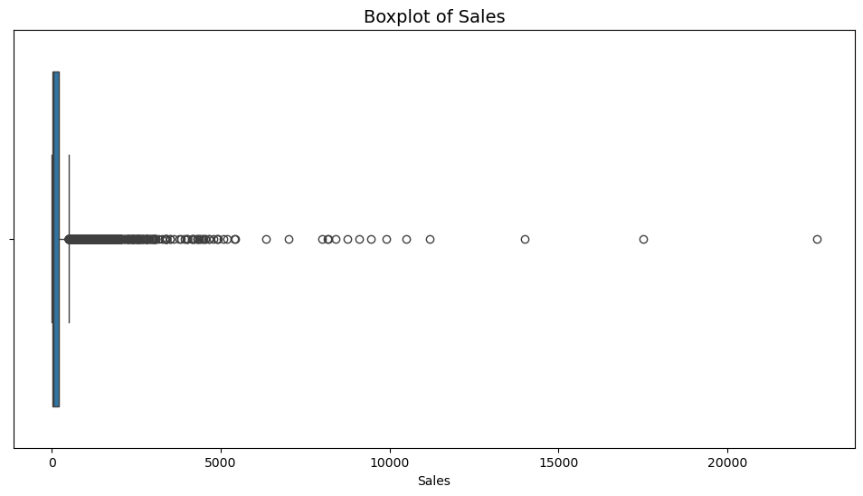

```python
import seaborn as sns
import matplotlib.pyplot as plt

plt.figure(figsize=(12,6))
sns.boxplot(x=df_clean['Sales'])
plt.title("Boxplot of Sales", fontsize=14)
plt.xlabel("Sales")
plt.show()
```

### 📊 Insight — Boxplot ستون Sales

در بررسی ستون Sales ابتدا نمودار Boxplot رسم شد تا الگوی توزیع داده‌ها مشخص شود. نمودار نشان داد که بخش زیادی از مقادیر فروش در محدوده‌های پایین قرار دارند، اما چند مقدار بسیار بزرگ در سمت راست نمودار دیده می‌شود که از نظر آماری Outlier محسوب می‌شوند.

این مقادیر بزرگ، Outlierهای طبیعی و واقعی هستند که معمولاً مربوط به فروش محصولات گران‌قیمت یا سفارش‌های بزرگ می‌باشند. به همین دلیل، Outlierهای ستون Sales حذف نشدند؛ زیرا حذف آن‌ها باعث از بین رفتن اطلاعات مهم تجاری و ایجاد تصویر غیرواقعی از رفتار فروش می‌شود.

در نتیجه، ستون Sales بدون حذف Outlierها وارد مرحلهٔ EDA شد تا تحلیل‌ها بر اساس داده‌های واقعی انجام شوند.

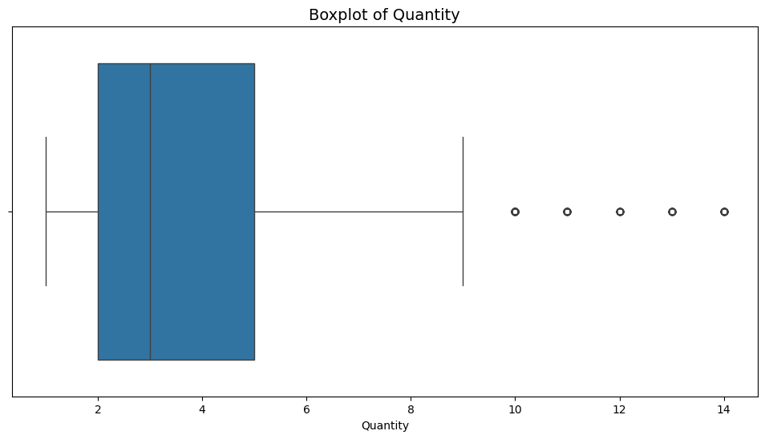

```python
import seaborn as sns
import matplotlib.pyplot as plt

plt.figure(figsize=(12,6))
sns.boxplot(x=df_clean['Quantity'])
plt.title("Boxplot of Quantity", fontsize=14)
plt.xlabel("Quantity")
plt.show()
```

```python
Q1 = df_clean['Quantity'].quantile(0.25)
Q3 = df_clean['Quantity'].quantile(0.75)
IQR = Q3 - Q1

Q1, Q3, IQR
```

```
(np.float64(2.0), np.float64(5.0), np.float64(3.0))
```

```python
lower_bound = Q1 - 1.5 * IQR
upper_bound = Q3 + 1.5 * IQR

lower_bound, upper_bound
```

```
(np.float64(-2.5), np.float64(9.5))
```

```python
outliers_quantity = df_clean[
    (df_clean['Quantity'] < lower_bound) |
    (df_clean['Quantity'] > upper_bound)
]

outliers_quantity.shape
```

```
(169, 21)
```

```python
df_clean = df_clean[
    (df_clean['Quantity'] >= lower_bound) &
    (df_clean['Quantity'] <= upper_bound)
]
```

```python
df_clean['Quantity'].describe()
```

```
count    9814.000000
mean        3.653862
std         1.978875
min         1.000000
25%         2.000000
50%         3.000000
75%         5.000000
max         9.000000
Name: Quantity, dtype: float64
```

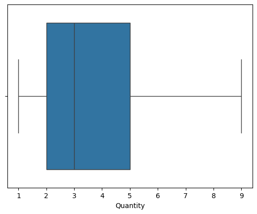

```python
import seaborn as sns
sns.boxplot(x=df_clean['Quantity'])
plt.show()
```

### 📊 Insight — Boxplot و IQR ستون Quantity

در بررسی ستون Quantity ابتدا نمودار Boxplot رسم شد تا توزیع داده‌ها و مقادیر پرت احتمالی شناسایی شوند. نمودار نشان داد که بخش قابل‌توجهی از مقادیر Quantity در بازه‌های پایین قرار دارند، در حالی که تعدادی مقدار بزرگ‌تر در سمت راست توزیع مشاهده می‌شود که از نظر آماری به‌عنوان Outlier شناخته می‌شوند.

برای شناسایی دقیق این مقادیر، روش IQR مورد استفاده قرار گرفت. در این مرحله، مقادیر Q1، Q3 و IQR محاسبه شده و محدودهٔ مجاز داده‌ها بر اساس کران‌های پایین و بالای IQR تعیین شد. نتایج نشان داد که مقادیر بزرگ‌تر از 9.5 خارج از این محدوده قرار گرفته و از نظر آماری Outlier محسوب می‌شوند.

با توجه به هدف تحلیل و برای جلوگیری از انحراف در بررسی الگوی خرید مشتریان، این مقادیر پرت از دیتاست حذف شدند. پس از حذف Outlierها، توزیع Quantity منظم‌تر شد و داده‌ها رفتار واقعی‌تری از الگوی سفارش‌ها را نشان دادند. این پاک‌سازی باعث شد ستون Quantity با دقت بیشتری وارد مرحلهٔ EDA شود و تحلیل‌ها قابل‌اعتمادتر باشند.

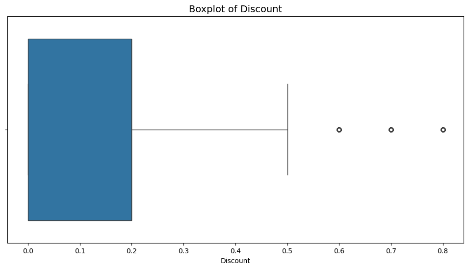

```python
plt.figure(figsize=(12,6))
sns.boxplot(x=df_clean['Discount'])
plt.title("Boxplot of Discount", fontsize=14)
plt.xlabel("Discount")
plt.show()
```

### 📊 Insight — Boxplot ستون Discount

در بررسی ستون Discount ابتدا نمودار Boxplot رسم شد تا توزیع تخفیف‌ها و وجود مقادیر پرت احتمالی بررسی شود. نمودار نشان داد که بخش عمدهٔ مقادیر Discount در بازهٔ ۰ تا ۰.۳ متمرکز هستند، در حالی که تعدادی مقدار بالاتر نیز در سمت راست توزیع مشاهده می‌شود.

بر اساس معیار IQR، برخی از این مقادیر از نظر آماری به‌عنوان Outlier شناسایی شدند. با این حال، بررسی ماهیت داده‌ها نشان داد که این مقادیر لزوماً ناشی از خطا نیستند؛ تخفیف‌های بالاتر تا حدود ۰.۸ (۸۰٪) در دیتاست وجود دارند و بیانگر سیاست‌های واقعی تخفیف در فروش هستند.

به همین دلیل، Outlierهای ستون Discount حذف نشدند؛ زیرا حذف آن‌ها می‌تواند اطلاعات ارزشمندی دربارهٔ استراتژی‌های تخفیف و تأثیر آن‌ها بر Sales و Profit را از بین ببرد. در نتیجه، ستون Discount با حفظ این مقادیر وارد مرحلهٔ EDA شد تا رفتار واقعی تخفیف‌ها و نقش آن‌ها در عملکرد فروش و سود بررسی شود.

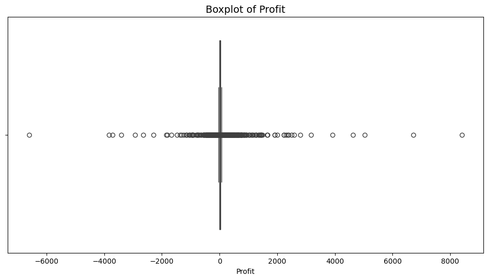

```python
plt.figure(figsize=(12,6))
sns.boxplot(x=df_clean['Profit'])
plt.title("Boxplot of Profit", fontsize=14)
plt.xlabel("Profit")
plt.show()
```

### 📊 Insight — Boxplot ستون Profit

در بررسی ستون Profit ابتدا نمودار Boxplot رسم شد تا توزیع سود و زیان و وجود مقادیر پرت احتمالی مشخص شود. نمودار نشان داد که بخش قابل‌توجهی از مقادیر Profit در محدودهٔ نزدیک به صفر قرار دارند، در حالی که تعدادی مقدار بسیار بزرگ در سمت راست و همچنین مقادیر منفی در سمت چپ نمودار مشاهده می‌شوند که از نظر آماری Outlier محسوب می‌شوند.

وجود مقادیر منفی در ستون Profit نشان‌دهندهٔ سفارش‌هایی است که در آن‌ها زیان مالی ثبت شده است. این مقادیر واقعی هستند و می‌توانند ناشی از تخفیف‌های زیاد، هزینه‌های بالا یا سیاست‌های فروش باشند. همچنین مقادیر بسیار بزرگ Profit نیز بیانگر سفارش‌ها یا محصولات با سودآوری بالا هستند و بخشی از رفتار طبیعی دیتاست محسوب می‌شوند.

با توجه به ماهیت مالی ستون Profit، Outlierها حذف نشدند؛ زیرا این مقادیر اطلاعات ارزشمندی دربارهٔ سفارش‌های سودآور و زیان‌ده ارائه می‌کنند و حذف آن‌ها باعث از دست رفتن بخش مهمی از واقعیت عملکرد مالی می‌شود.

در نتیجه، ستون Profit بدون حذف Outlierها وارد مرحلهٔ EDA شد تا در مراحل بعدی، عوامل مؤثر بر سود و زیان — از جمله Sales و Discount — با دقت بیشتری تحلیل شوند.

### 🧹 Insight نهایی مرحلهٔ Cleaning — پروژه Superstore

برای بررسی مقادیر پرت، نمودارهای Boxplot برای چهار ستون اصلی رسم شد:

- Sales: مقادیر بسیار بزرگ مشاهده شدند که واقعی بوده و مربوط به سفارش‌های بزرگ یا محصولات گران‌قیمت هستند؛ بنابراین حذف نشدند.
- Quantity: با استفاده از روش IQR، مقادیر بزرگ‌تر از 9.5 به‌عنوان Outlier شناسایی و حذف شدند تا توزیع Quantity منظم‌تر و واقعی‌تر شود.
- Discount: تخفیف‌های بالاتر تا حدود 0.8 مشاهده شدند که واقعی بوده و بخشی از سیاست‌های فروش هستند؛ بنابراین حذف نشدند.
- Profit: وجود مقادیر منفی و بسیار بزرگ مشاهده شد که نشان‌دهندهٔ سفارش‌های زیان‌ده یا بسیار سودآور هستند؛ بنابراین حذف نشدند تا تصویر واقعی عملکرد مالی حفظ شود.

در مجموع، Cleaning به‌گونه‌ای انجام شد که داده‌ها هم از نظر کیفیت بهبود پیدا کنند و هم ماهیت واقعی رفتار فروش، تخفیف، سودآوری و الگوی سفارش‌ها حفظ شود. این رویکرد باعث شد دیتاست Superstore آمادهٔ انجام تحلیل‌های دقیق‌تر در مرحلهٔ EDA باشد.

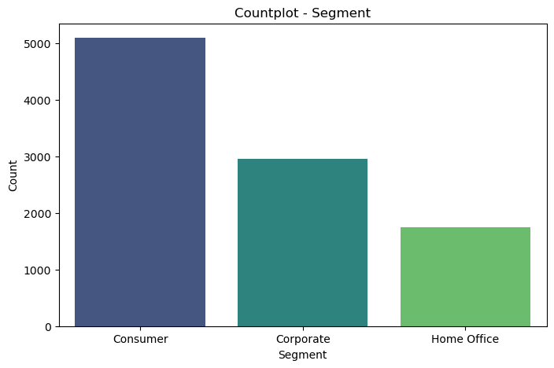

```python
plt.figure(figsize=(8,5))
sns.countplot(data=df_clean, x='Segment', hue='Segment', palette='viridis', legend=False)

plt.title('Countplot - Segment')
plt.xlabel('Segment')
plt.ylabel('Count')
plt.show()
```

### 📊 Insight — Countplot ستون Segment

نمودار Countplot ستون Segment نشان می‌دهد که توزیع سفارش‌ها میان سه گروه مشتریان کاملاً نامتعادل است. گروه Consumer با اختلاف قابل‌توجهی بیشترین تعداد سفارش را به خود اختصاص داده و پس از آن گروه Corporate قرار دارد. گروه Home Office کمترین سهم را در میان سگمنت‌های مشتریان دارد.

این الگو نشان می‌دهد که تمرکز اصلی فروش فروشگاه بر مشتریان خرد (Consumer) است. این موضوع می‌تواند در تحلیل‌های بعدی — مانند بررسی سودآوری هر بخش، تأثیر تخفیف‌ها بر رفتار خرید هر گروه، و طراحی استراتژی‌های بازاریابی متناسب با هر سگمنت — نقش کلیدی داشته باشد. شناخت این توزیع به ما کمک می‌کند مسیر تحلیل‌های تجاری را دقیق‌تر و هدفمندتر دنبال کنیم.

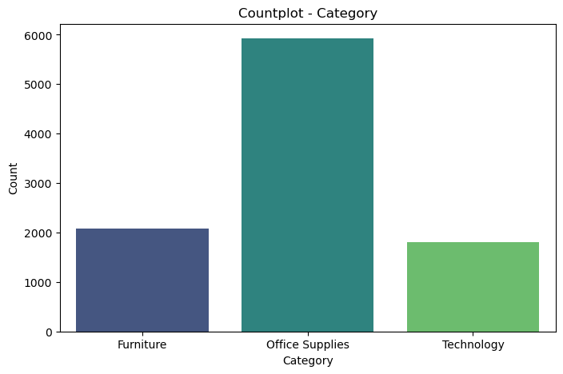

```python
plt.figure(figsize=(8,5))
sns.countplot(data=df_clean, x='Category', hue='Category', palette='viridis', legend=False)

plt.title('Countplot - Category')
plt.xlabel('Category')
plt.ylabel('Count')
plt.show()
```

### 📊 Insight — Countplot ستون Category

این تفاوت در حجم سفارش‌ها می‌تواند ناشی از عواملی مانند تفاوت در قیمت واحد محصولات، میزان نیاز و تقاضای مشتریان، یا سیاست‌های فروش هر دسته باشد. این الگو اهمیت زیادی در تحلیل‌های بعدی دارد؛ زیرا می‌تواند بر بررسی سودآوری هر دسته، تأثیر تخفیف‌ها بر فروش و شناسایی بخش‌های سودآور یا کم‌سود تأثیر مستقیم داشته باشد.

شناخت این توزیع به ما کمک می‌کند مسیر تحلیل‌های تجاری را هدفمندتر دنبال کنیم و در مراحل بعدی، رفتار فروش هر دسته را با دقت بیشتری بررسی کنیم.

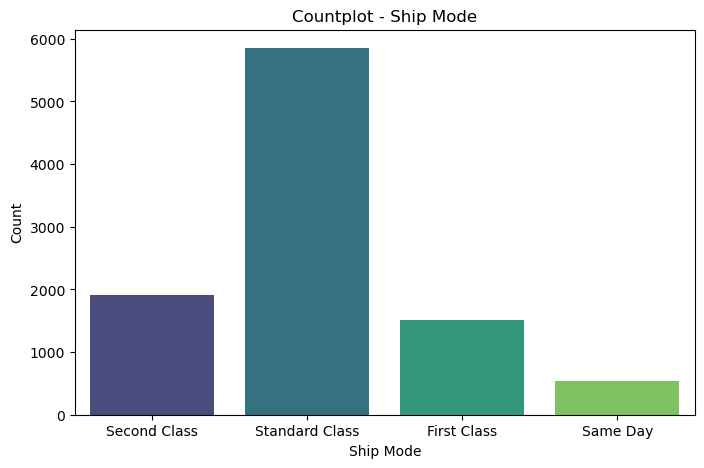

```python
plt.figure(figsize=(8,5))
sns.countplot(data=df_clean, x='Ship Mode', hue='Ship Mode', palette='viridis', legend=False)

plt.title('Countplot - Ship Mode')
plt.xlabel('Ship Mode')
plt.ylabel('Count')
plt.show()
```

### 📦 Insight — Countplot ستون Ship Mode

نمودار Countplot ستون Ship Mode نشان می‌دهد که توزیع روش‌های ارسال سفارش‌ها میان چهار حالت اصلی یکسان نیست. بیشترین تعداد سفارش‌ها با روش Standard Class انجام شده است؛ روشی که معمولاً کم‌هزینه‌تر بوده و برای اکثر مشتریان گزینهٔ پیش‌فرض محسوب می‌شود. پس از آن روش‌های Second Class و First Class قرار می‌گیرند و در نهایت Same Day کمترین سهم را دارد.

این الگو می‌تواند بازتاب ترجیح مشتریان برای انتخاب روش‌های ارسال مقرون‌به‌صرفه باشد، هرچند این فرضیه نیازمند بررسی دقیق‌تر ستون‌های دیگر مانند Profit و Sales است تا مشخص شود آیا روش ارسال واقعاً بر سودآوری یا حجم فروش تأثیر دارد یا خیر. این تفاوت در توزیع Ship Mode می‌تواند در تحلیل‌های بعدی — مانند بررسی رابطهٔ نوع ارسال با Discount یا تحلیل زمان تحویل — نقش مهمی داشته باشد.

شناخت این توزیع به ما کمک می‌کند رفتار مشتریان را بهتر درک کنیم و مسیر تحلیل‌های تجاری را در مراحل بعدی EDA هدفمندتر دنبال کنیم.

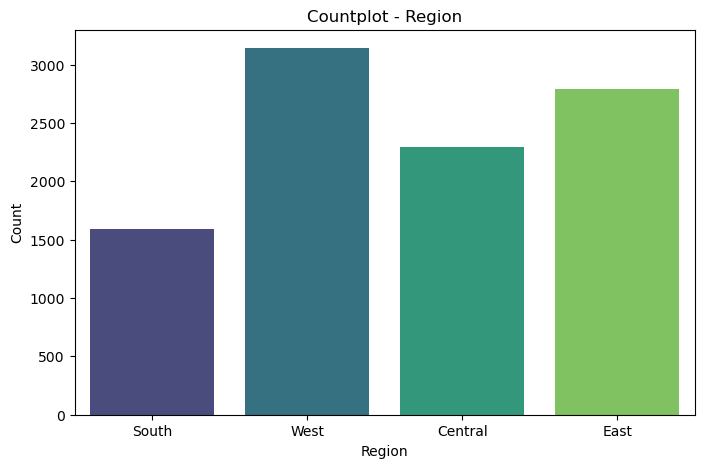

```python
plt.figure(figsize=(8,5))
sns.countplot(data=df_clean, x='Region', hue='Region', palette='viridis', legend=False)

plt.title('Countplot - Region')
plt.xlabel('Region')
plt.ylabel('Count')
plt.show()
```

### 🌍 Insight — Countplot ستون Region

نمودار Countplot ستون Region نشان می‌دهد که توزیع سفارش‌ها میان چهار منطقهٔ اصلی فروشگاه یکسان نیست. بیشترین تعداد سفارش‌ها مربوط به منطقهٔ West است و پس از آن مناطق East و Central قرار می‌گیرند. منطقهٔ South کمترین تعداد سفارش را دارد.

این الگو نشان می‌دهد که فعالیت فروشگاه در مناطق مختلف یکسان نیست و برخی مناطق سهم بیشتری در حجم سفارش‌ها دارند. این تفاوت می‌تواند ناشی از عوامل مختلفی مانند تراکم جمعیت، قدرت خرید، تعداد مشتریان فعال، یا سیاست‌های منطقه‌ای فروش باشد. بررسی دقیق‌تر این الگو در مراحل بعدی — مانند تحلیل سودآوری هر منطقه، بررسی تأثیر تخفیف‌ها، یا مقایسهٔ عملکرد فروش در دسته‌های مختلف محصول — می‌تواند بینش‌های ارزشمندی ارائه دهد.

شناخت این توزیع به ما کمک می‌کند رفتار فروش در مناطق مختلف را بهتر درک کنیم و مسیر تحلیل‌های تجاری را در ادامهٔ EDA هدفمندتر دنبال کنیم.

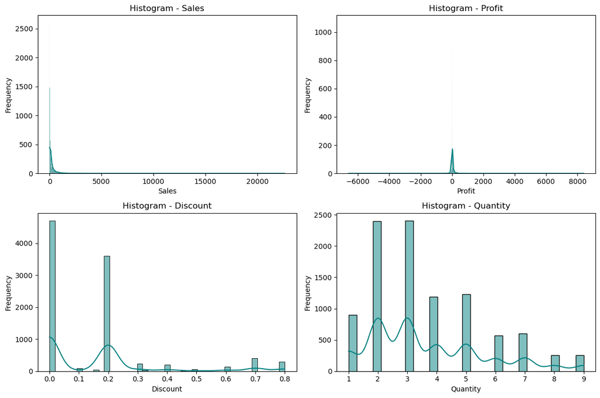

```python
numerical_cols = ['Sales', 'Profit', 'Discount', 'Quantity']

plt.figure(figsize=(12,8))

for i, col in enumerate(numerical_cols, 1):
    plt.subplot(2, 2, i)
    sns.histplot(data=df_clean, x=col, kde=True, color='teal')
    plt.title(f'Histogram - {col}')
    plt.xlabel(col)
    plt.ylabel('Frequency')

plt.tight_layout()
plt.show()
```

### 📊 Insight — Histogram ستون‌های عددی (Sales, Profit, Discount, Quantity)

بررسی چهار Histogram مربوط به ستون‌های عددی دیتاست Superstore نشان می‌دهد که رفتار این متغیرها کاملاً ناهمگون است و هرکدام الگوی توزیع متفاوتی دارند. ستون Sales دارای توزیع شدیداً Right-Skewed است؛ یعنی بخش عمدهٔ فروش‌ها در بازه‌های پایین قرار دارند و تنها تعداد کمی سفارش با مبلغ بسیار بالا ثبت شده است. ستون Profit نیز پراکندگی زیادی دارد و وجود مقادیر مثبت و منفی نشان می‌دهد که همهٔ فروش‌ها الزاماً سودآور نبوده‌اند.

در ستون Discount دو پیک اصلی دیده می‌شود که نشان‌دهندهٔ استفادهٔ غالب از تخفیف‌های ۰٪ و ۲۰٪ است؛ این الگو می‌تواند ناشی از سیاست‌های ثابت تخفیف در فروشگاه باشد. ستون Quantity نیز نشان می‌دهد که بیشتر سفارش‌ها شامل تعداد کم (معمولاً ۲ یا ۳ عدد) هستند و سفارش‌های با تعداد بالا بسیار کمتر دیده می‌شوند.

این چهار توزیع در کنار هم تصویری روشن از رفتار عددی دیتاست ارائه می‌دهند:  
فروش‌ها و سود پراکندگی بالا دارند، تخفیف‌ها الگوی ثابت و قابل‌پیش‌بینی دارند، و تعداد اقلام سفارش معمولاً کم است. این بینش‌ها در مراحل بعدی تحلیل — مانند بررسی سودآوری، تأثیر تخفیف‌ها، یا رفتار خرید مشتریان — نقش کلیدی خواهند داشت.

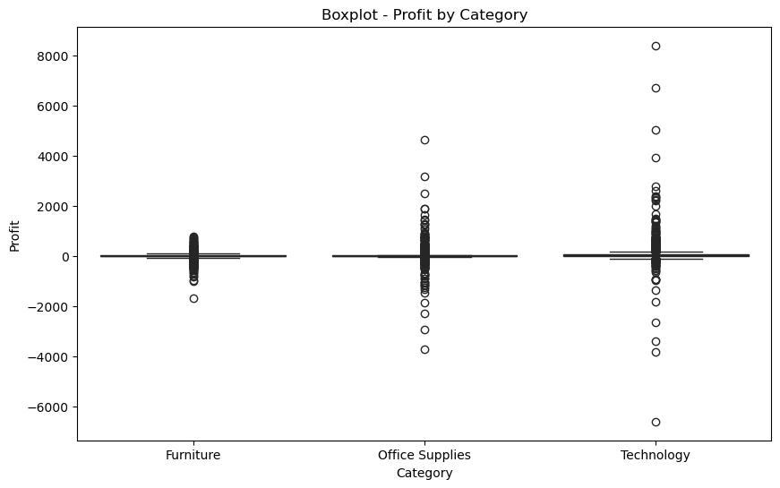

```python
plt.figure(figsize=(10,6))
sns.boxplot(data=df_clean, x='Category', y='Profit', color='teal')

plt.title('Boxplot - Profit by Category')
plt.xlabel('Category')
plt.ylabel('Profit')
plt.show()
```

### 💰 Insight — Boxplot ستون Profit بر اساس Category

نمودار Boxplot ستون Profit بر اساس Category نشان می‌دهد که رفتار سودآوری در سه دستهٔ اصلی محصولات کاملاً متفاوت است.  
دستهٔ Technology بیشترین پراکندگی سود را دارد و وجود مقادیر بالا در این دسته نشان می‌دهد که محصولات تکنولوژی می‌توانند سود قابل‌توجهی ایجاد کنند، هرچند Outlierهای منفی نیز دیده می‌شود که بیانگر ریسک زیان در برخی سفارش‌هاست.

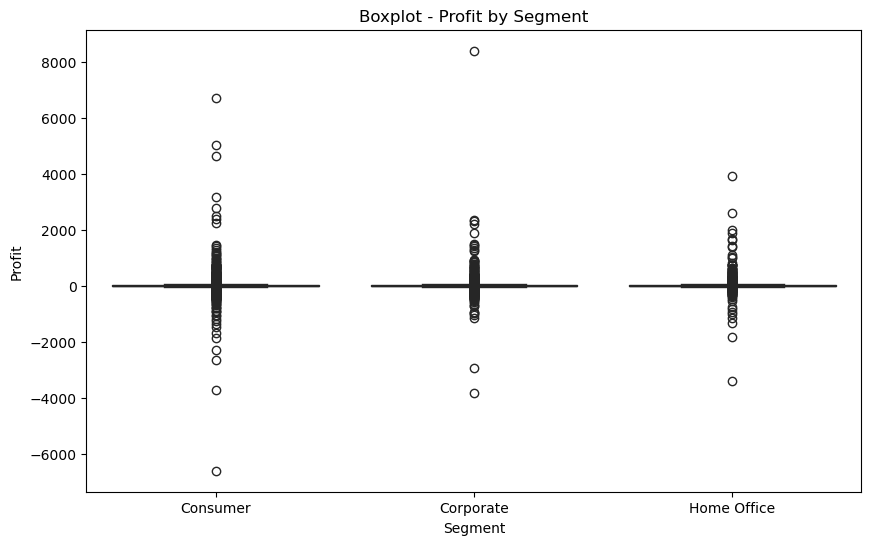

```python
plt.figure(figsize=(10,6))
sns.boxplot(data=df_clean, x='Segment', y='Profit', color='teal')

plt.title('Boxplot - Profit by Segment')
plt.xlabel('Segment')
plt.ylabel('Profit')
plt.show()
```

### 👥 Insight — Boxplot ستون Profit بر اساس Segment

نمودار Boxplot ستون Profit بر اساس Segment نشان می‌دهد که سه گروه مشتریان (Consumer، Corporate، Home Office) از نظر سودآوری رفتار یکسانی ندارند.

این یافته نشان می‌دهد که ریسک مالی به‌طور یکسان بین Segmentها توزیع نشده و می‌تواند مسیر تحلیل‌های بعدی — مانند بررسی رابطهٔ Discount با Profit در هر Segment — را مشخص کند.

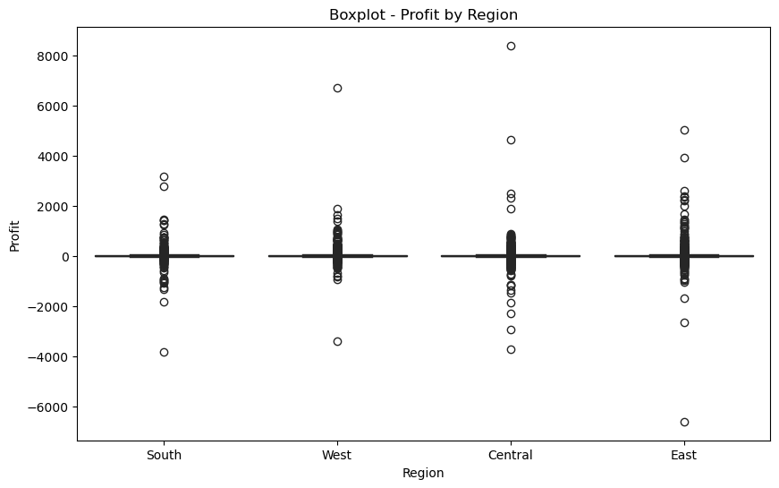

```python
plt.figure(figsize=(10,6))
sns.boxplot(data=df_clean, x='Region', y='Profit', color='teal')

plt.title('Boxplot - Profit by Region')
plt.xlabel('Region')
plt.ylabel('Profit')
plt.show()
```

### 🌍 Insight — Boxplot ستون Profit بر اساس Region

نمودار Boxplot ستون Profit بر اساس Region نشان می‌دهد که سودآوری در چهار منطقهٔ اصلی (West، East، Central، South) یکسان نیست و هر منطقه رفتار مالی متفاوتی دارد.

مناطق East و Central رفتار نسبتاً مشابهی دارند؛ سودها عمدتاً در بازه‌های میانی و پایدارتری قرار می‌گیرند، هرچند Central نسبت به East پراکندگی و مقادیر منفی بیشتری نشان می‌دهد.

این تفاوت‌ها نشان می‌دهد ریسک مالی در مناطق مختلف یکسان توزیع نشده و می‌تواند مسیر تحلیل‌های بعدی — مانند بررسی رابطهٔ Discount با Profit در هر Region — را مشخص کند.

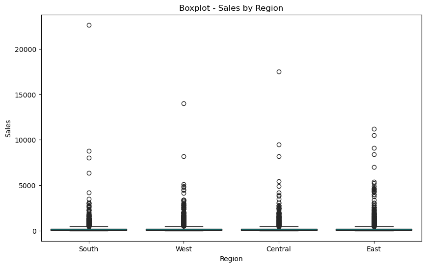

```python
plt.figure(figsize=(10,6))
sns.boxplot(data=df_clean, x='Region', y='Sales', color='teal')

plt.title('Boxplot - Sales by Region')
plt.xlabel('Region')
plt.ylabel('Sales')
plt.show()
```

### 🌍 Insight — Boxplot ستون Sales بر اساس Region

نمودار Boxplot ستون Sales بر اساس Region نشان می‌دهد که میزان فروش در چهار منطقهٔ اصلی (West، East، Central، South) یکسان نیست و هر منطقه الگوی متفاوتی از رفتار فروش دارد.

مناطق East و Central رفتار نسبتاً مشابهی دارند و فروش عمدتاً در بازه‌های میانی و پایدارتری قرار می‌گیرد، هرچند Central پراکندگی کمی بیشتر و چند سفارش با مبلغ بالاتر نشان می‌دهد.

این تفاوت‌ها نشان می‌دهد رفتار فروش در مناطق مختلف یکسان نیست و می‌تواند مسیر تحلیل‌های بعدی — مانند بررسی تأثیر تخفیف‌ها بر فروش در هر Region — را مشخص کند.

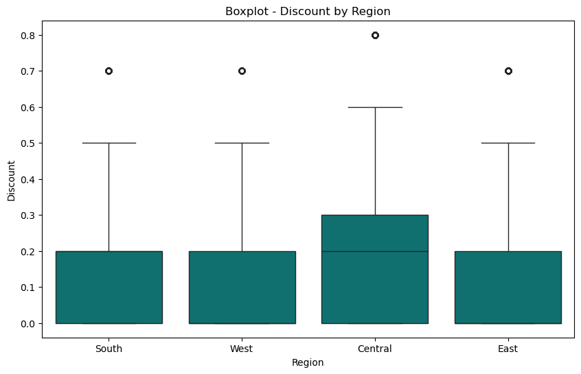

```python
plt.figure(figsize=(10,6))
sns.boxplot(data=df_clean, x='Region', y='Discount', color='teal')

plt.title('Boxplot - Discount by Region')
plt.xlabel('Region')
plt.ylabel('Discount')
plt.show()
```

### 🌍 Insight — Boxplot ستون Discount بر اساس Region

نمودار Boxplot ستون Discount بر اساس Region نشان می‌دهد که میزان تخفیف در چهار منطقهٔ اصلی (West، East، Central، South) الگوی یکسانی ندارد و رفتار تخفیف‌دهی در هر منطقه متفاوت است.

این تفاوت‌ها نشان می‌دهد رفتار تخفیف‌دهی در مناطق مختلف یکسان نیست و می‌تواند مسیر تحلیل‌های بعدی — مانند بررسی تأثیر تخفیف بر سودآوری در هر Region — را مشخص کند.

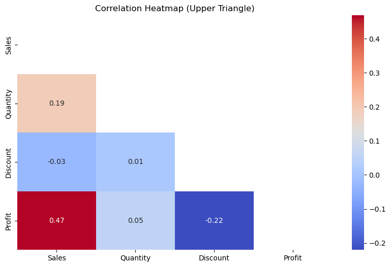

```python
import numpy as np
corr = df_clean.corr(numeric_only=True)
mask = np.triu(np.ones_like(corr))

plt.figure(figsize=(10,6))
sns.heatmap(corr, mask=mask, annot=True, cmap='coolwarm', fmt='.2f')
plt.title('Correlation Heatmap (Upper Triangle)')
plt.show()
```

### 🔥 Insight — Correlation Heatmap

ماتریس همبستگی نشان می‌دهد که میان متغیرهای عددی دیتاست Superstore رابطه‌های خطی مشخصی وجود دارد، اما شدت این روابط در همهٔ موارد یکسان نیست و هر متغیر رفتار متفاوتی نشان می‌دهد.

Profit بیشترین همبستگی مثبت را با Sales دارد (حدود ۰.۴۷). این عدد نشان‌دهندهٔ یک رابطهٔ مثبت اما متوسط است؛ یعنی هرچه فروش بیشتر باشد، سود هم گرایش به افزایش دارد، ولی این رابطه به‌قدری قوی نیست که فروش بالا را تضمینی برای سود بالا بداند — عوامل دیگری مانند تخفیف نیز نقش دارند.

Discount همبستگی منفی با Profit دارد (حدود ۰.۲۲-). این یعنی تخفیف‌های بالا معمولاً با کاهش سود همراه‌اند؛ الگویی که در بررسی سیاست‌های قیمت‌گذاری و تخفیف اهمیت دارد.

Quantity تقریباً هیچ رابطهٔ خطی قابل‌توجهی با سایر متغیرها ندارد (بین ۰.۰۱ تا ۰.۱۹). این نشان می‌دهد تعداد کالای خریداری‌شده، به‌تنهایی، تأثیر چندانی نه بر فروش و نه بر سود ندارد و احتمالاً نوع و قیمت محصول عامل مهم‌تری است.

در مجموع، Profit بیشتر تحت تأثیر Sales و Discount قرار دارد تا Quantity، و این بینش می‌تواند مسیر تحلیل‌های بعدی — مانند بررسی تأثیر تخفیف بر سود در سطح Category — را مشخص کند.

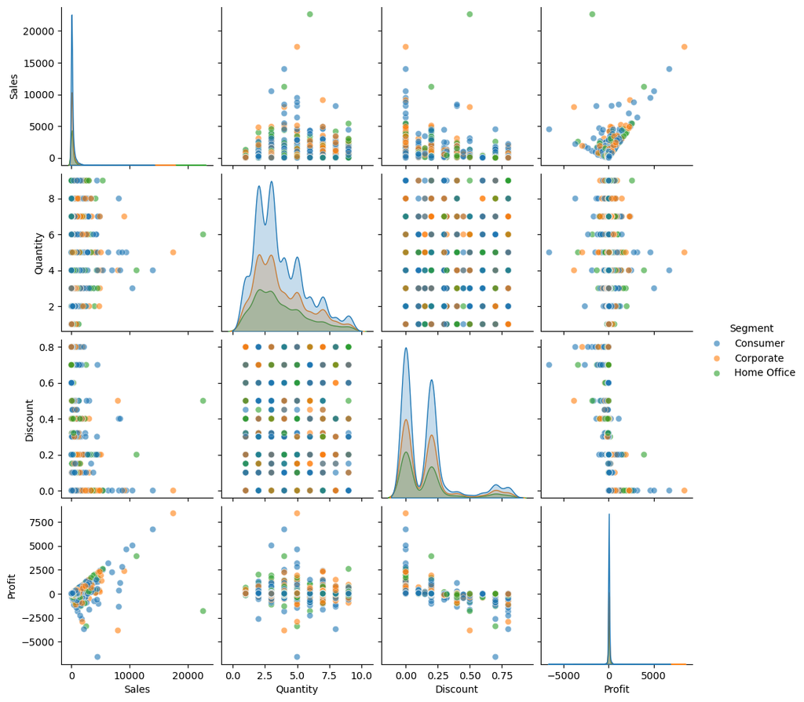

```python
sns.pairplot(df_clean,
             vars=['Sales', 'Quantity', 'Discount', 'Profit'],
             hue='Segment',
             diag_kind='kde',
             plot_kws={'alpha':0.6, 's':40},
             height=2.5)
plt.show()
```

### 🌈 Insight — Pairplot (Sales, Quantity, Discount, Profit)

نمودار Pairplot روابط بین چهار متغیر عددی اصلی دیتاست Superstore را نشان می‌دهد و با رنگ‌بندی بر اساس Segment، امکان مقایسهٔ رفتار سه گروه مشتری (Consumer، Corporate، Home Office) را نیز فراهم می‌کند.

Sales ↔ Profit رابطهٔ مثبت و قابل‌مشاهده‌ای دارد؛ هرچه فروش بیشتر باشد، سود نیز گرایش به افزایش دارد. با این حال پراکندگی نقاط نشان می‌دهد این رابطه قطعی نیست و عواملی مانند تخفیف یا نوع محصول می‌توانند آن را تغییر دهند.

Discount ↔ Profit الگوی منفی نشان می‌دهد؛ یعنی تخفیف‌های بالا معمولاً با کاهش سود همراه‌اند. این یکی از مهم‌ترین الگوهای قابل‌مشاهده در این نمودار است.

Quantity با Sales و Profit رابطهٔ خطی ضعیفی دارد، که نشان می‌دهد تعداد کالای خریداری‌شده، به‌تنهایی، عامل تعیین‌کننده‌ای برای فروش یا سود نیست؛ نوع و قیمت محصول احتمالاً نقش مهم‌تری دارند.

نقاط مربوط به Segmentهای مختلف (به‌ویژه Home Office) در برخی نواحی از نمودار با سایر گروه‌ها همپوشانی دارند، ولی در برخی نقاط دیگر به‌طور نسبی از بقیه جدا می‌شوند؛ این یعنی تفکیک کامل بین Segmentها وجود ندارد، ولی الگوی کاملاً یکسانی هم دیده نمی‌شود.

نمودارهای KDE روی قطر Pairplot نیز نشان می‌دهند که توزیع متغیرها یکسان نیست: Sales و Profit توزیع‌های کشیده و right-skewed دارند، در حالی‌که Discount توزیعی محدودتر و متمرکزتر نشان می‌دهد.

در مجموع، Profit بیشترین وابستگی را به Sales و Discount نشان می‌دهد و Quantity نقش کم‌رنگ‌تری در سودآوری دارد. این بینش‌ها می‌تواند مسیر تحلیل‌های بعدی — مانند مدل‌سازی Profit یا بررسی دقیق‌تر تأثیر Discount — را مشخص کند.

### 🧠 Insight نهایی پروژهٔ EDA — Superstore Dataset

تحلیل اکتشافی داده‌ها (EDA) روی دیتاست Superstore نشان داد که رفتار فروش، سود، تخفیف و الگوهای خرید مشتریان در بخش‌های مختلف کسب‌وکار یکسان نیست و هر بخش ویژگی‌های آماری و تجاری متفاوتی دارد.

#### 📌 ۲) رفتار سود (Profit)

سود بیشترین همبستگی را با Sales دارد (رابطهٔ مثبت و متوسط).  
Discount تأثیر منفی قابل‌توجهی بر سود نشان می‌دهد؛ یعنی تخفیف‌های بالا معمولاً با کاهش سودآوری همراه‌اند — یکی از مهم‌ترین بینش‌های تجاری این دیتاست.

#### 📌 ۴) رفتار مشتریان (Segment)

در Pairplot، نقاط مربوط به سه گروه مشتری (Consumer، Corporate، Home Office) در برخی نواحی با هم همپوشانی دارند و در برخی نواحی دیگر نسبتاً از هم جدا می‌شوند؛ یعنی تفکیک کاملی بین Segmentها دیده نمی‌شود، اما الگوی یکسانی هم ندارند. بررسی دقیق‌تر این تفاوت‌ها می‌تواند در تحلیل‌های بازاریابی مفید باشد.

#### 📌 ۵) همبستگی‌ها (Correlation)

ماتریس همبستگی نشان داد که:

- Profit بیشترین وابستگی را به Sales دارد
- Discount رابطهٔ منفی با Profit دارد
- Quantity تقریباً هیچ رابطهٔ خطی مهمی با سایر متغیرها ندارد

این یعنی سودآوری بیشتر تحت تأثیر قیمت و تخفیف است تا تعداد کالاها.

#### 📌 ۶) جمع‌بندی نهایی

در مجموع، EDA نشان می‌دهد که:

- رفتار فروش و سود در مناطق مختلف متفاوت است
- تخفیف‌ها نقش مهمی در کاهش سود دارند
- Segmentها تا حدی رفتار خرید متفاوتی نشان می‌دهند
- Quantity نقش کم‌رنگی در سودآوری دارد
- Sales و Profit مهم‌ترین ستون‌های عددی برای تحلیل‌های بعدی هستند

این بینش‌ها مسیر تحلیل‌های بعدی — مانند مدل‌سازی سود، تحلیل تأثیر تخفیف، یا ساخت داشبوردهای مدیریتی — را مشخص می‌کنند و پایهٔ محکمی برای ادامهٔ پروژه فراهم می‌کنند.

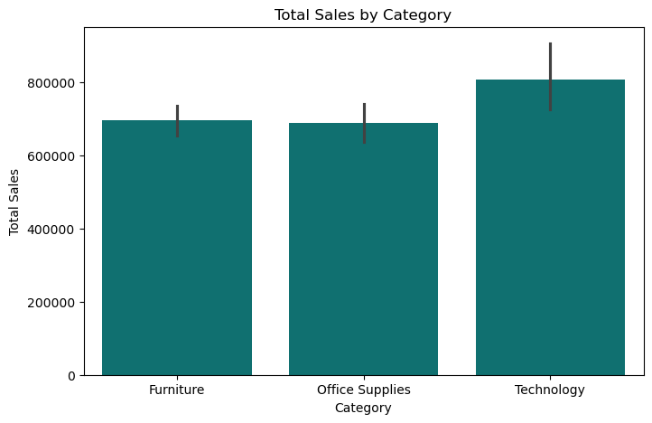

```python
plt.figure(figsize=(8,5))
sns.barplot(data=df_clean, x='Category', y='Sales', estimator='sum', color='teal')
plt.title('Total Sales by Category')
plt.xlabel('Category')
plt.ylabel('Total Sales')
plt.xticks(rotation=0)
plt.show()
```

### 📊 Insight — Sales by Category

نمودار Sales by Category نشان می‌دهد که میزان فروش کل در میان سه دسته‌بندی اصلی محصولات Superstore یکسان نیست.

بیشترین فروش مربوط به دستهٔ Technology است. این می‌تواند بازتاب قیمت واحد بالاتر محصولات این دسته باشد، هرچند تأیید این فرضیه نیاز به بررسی مستقیم قیمت‌ها یا Sub-Categoryهای این گروه دارد.

دستهٔ Furniture در ردهٔ بعدی قرار دارد، با فروشی نزدیک به Technology. Office Supplies کمترین فروش کل را دارد؛ نکتهٔ جالب این‌جاست که این دسته در Countplot پیشین، بیشترین تعداد سفارش را داشت — یعنی با اینکه پرتقاضاترین دسته است، به‌دلیل قیمت واحد پایین‌تر محصولاتش، در مجموع فروش کمتری نسبت به دو دستهٔ دیگر تولید می‌کند.

در مجموع، این نمودار نشان می‌دهد که Technology بیشترین سهم را در درآمد کل فروشگاه دارد، در حالی که Office Supplies با وجود تعداد سفارش بالا، سهم کمتری در فروش کل ایجاد می‌کند. این تفاوت می‌تواند در تصمیم‌گیری‌های مربوط به موجودی و برنامه‌ریزی فروش مفید باشد.

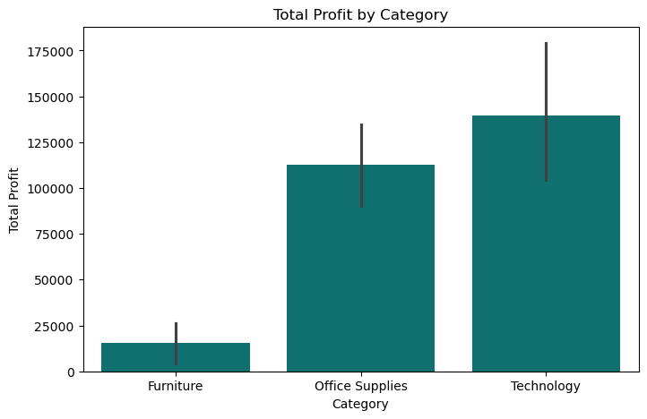

```python
plt.figure(figsize=(8,5))
sns.barplot(data=df_clean, x='Category', y='Profit', estimator='sum', color='teal')
plt.title('Total Profit by Category')
plt.xlabel('Category')
plt.ylabel('Total Profit')
plt.xticks(rotation=0)
plt.show()
```

### 💰 Insight — Profit by Category

نمودار Profit by Category نشان می‌دهد که سودآوری سه دسته‌بندی اصلی محصولات Superstore تفاوت قابل‌توجهی دارد.

بیشترین سود مربوط به دستهٔ Technology است — همان دسته‌ای که در نمودار Sales by Category نیز بیشترین فروش را داشت. این هم‌سویی نشان می‌دهد که Technology هم از نظر فروش و هم از نظر سود، دستهٔ برتر فروشگاه است.

Office Supplies با اینکه فروش کل کمتری نسبت به Technology داشت، سود قابل‌توجهی ثبت کرده و در رتبهٔ دوم قرار می‌گیرد.

نکتهٔ جالب‌توجه مربوط به دستهٔ Furniture است: با وجود اینکه فروش این دسته در نمودار قبلی نزدیک به Technology بود، سودش به‌طور چشمگیری پایین‌تر از هر دو دستهٔ دیگر است. این تناقض نشان می‌دهد فروش بالا لزوماً به سود بالا منجر نمی‌شود و عواملی مانند تخفیف یا هزینه‌های مرتبط با این دسته می‌توانند سودآوری آن را کاهش دهند — موضوعی که بررسی دقیق‌تر آن (مثلاً رابطهٔ Discount با Profit در سطح Furniture) می‌تواند در تحلیل‌های بعدی روشن‌تر شود.

در مجموع، Technology سودآورترین دستهٔ فروشگاه است، در حالی که Furniture علی‌رغم فروش بالا، ضعیف‌ترین عملکرد سودی را دارد. این بینش می‌تواند در تصمیم‌گیری‌های مربوط به قیمت‌گذاری و سیاست‌های تخفیف نقش مهمی داشته باشد.

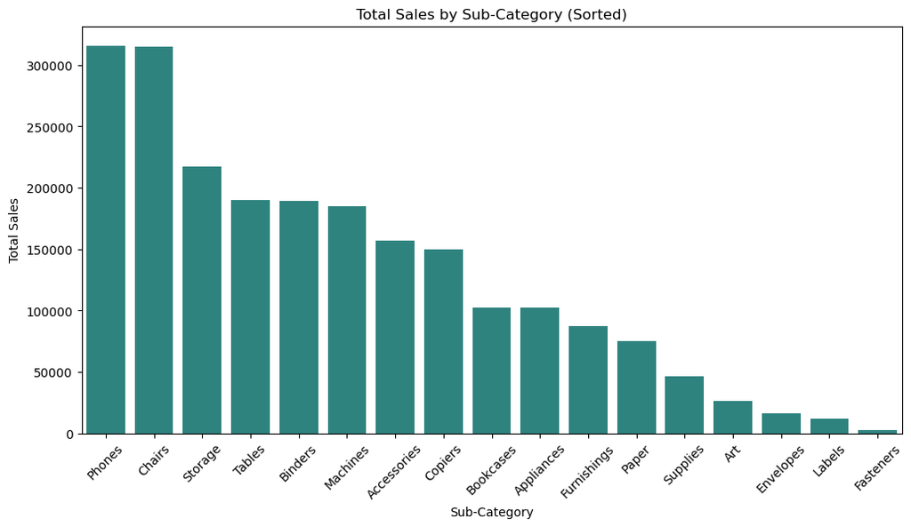

```python
sales_sub = df_clean.groupby('Sub-Category')['Sales'].sum().reset_index().sort_values('Sales', ascending=False)
sales_sub['dummy'] = 'A'

plt.figure(figsize=(12,6))
sns.barplot(data=sales_sub, x='Sub-Category', y='Sales', hue='dummy', palette='viridis')
plt.legend().remove()
plt.title('Total Sales by Sub-Category (Sorted)')
plt.xlabel('Sub-Category')
plt.ylabel('Total Sales')
plt.xticks(rotation=45)
plt.show()
```

### 📊 Insight — Sales by Sub-Category

نمودار Sales by Sub-Category نشان می‌دهد که میزان فروش در میان زیرگروه‌های مختلف محصولات Superstore تفاوت بسیار زیادی دارد.

بیشترین فروش مربوط به زیرگروه‌های Phones و Chairs است که با فاصلهٔ محسوسی از بقیه در صدر جدول قرار دارند. پس از آن‌ها، زیرگروه‌هایی مانند Storage، Tables، Binders، Machines، Accessories و Copiers در ردهٔ میانی قرار می‌گیرند و فروش نسبتاً قابل‌توجهی دارند.

کمترین فروش مربوط به زیرگروه‌های Fasteners، Labels و Envelopes است — این محصولات معمولاً قیمت واحد پایینی دارند، به همین دلیل حتی اگر تعداد سفارش‌شان زیاد باشد، مجموع فروش‌شان در مقایسه با زیرگروه‌های پرقیمت‌تر بسیار کمتر است.

در مجموع، این نمودار نشان می‌دهد فروش فروشگاه به‌شدت متمرکز بر تعداد محدودی از زیرگروه‌هاست (به‌ویژه Phones و Chairs)، در حالی‌که بسیاری از زیرگروه‌های دیگر سهم بسیار کوچکی از فروش کل دارند. این بینش می‌تواند در تصمیم‌گیری‌های مربوط به موجودی و اولویت‌بندی محصولات مفید باشد.

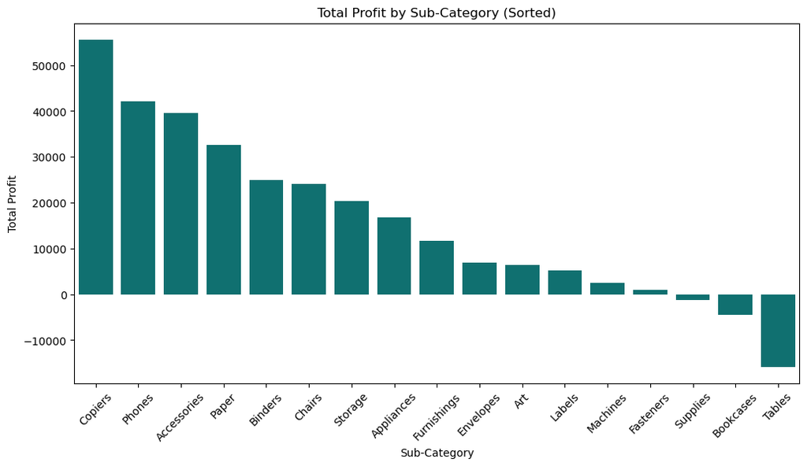

```python
profit_sub = df_clean.groupby('Sub-Category')['Profit'].sum().reset_index().sort_values('Profit', ascending=False)

plt.figure(figsize=(12,6))
sns.barplot(data=profit_sub, x='Sub-Category', y='Profit', color='teal')
plt.title('Total Profit by Sub-Category (Sorted)')
plt.xlabel('Sub-Category')
plt.ylabel('Total Profit')
plt.xticks(rotation=45)
plt.show()
```

### 💰 Insight — Profit by Sub-Category

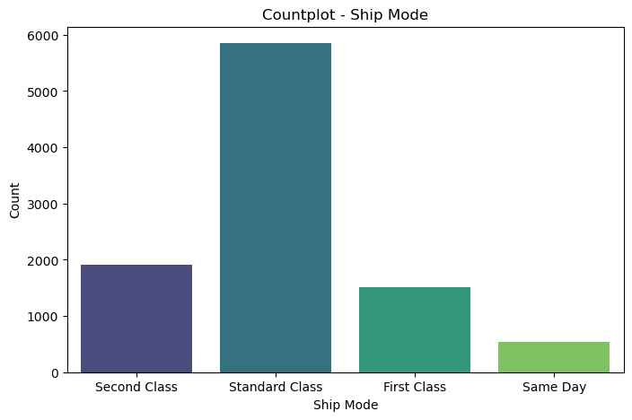

```python
plt.figure(figsize=(8,5))
sns.countplot(data=df_clean, x='Ship Mode', hue='Ship Mode', palette='viridis', legend=False)
plt.title('Countplot - Ship Mode')
plt.xlabel('Ship Mode')
plt.ylabel('Count')
plt.xticks(rotation=0)
plt.show()
```

### 🚚 Insight — Ship Mode

نمودار Countplot ستون Ship Mode نشان می‌دهد که توزیع تعداد سفارش‌ها میان چهار روش ارسال یکسان نیست.

1. بیشترین تعداد سفارش مربوط به Standard Class است که با فاصلهٔ زیادی از سایر روش‌ها در صدر قرار دارد.
2. Second Class در ردهٔ دوم قرار می‌گیرد، با تعداد سفارشی به‌مراتب کمتر از Standard Class.
3. First Class تعداد سفارش کمتری نسبت به دو روش قبلی دارد.
4. کمترین تعداد سفارش مربوط به Same Day است.

این الگو نشان می‌دهد که اکثریت قابل‌توجهی از مشتریان روش Standard Class را برای دریافت سفارش خود انتخاب می‌کنند، در حالی که سایر روش‌ها سهم بسیار کوچک‌تری دارند. دلیل این ترجیح (مانند تفاوت هزینه یا سرعت ارسال) در این نمودار قابل بررسی نیست و نیاز به داده‌های تکمیلی (مانند هزینهٔ هر روش ارسال) دارد. این بینش می‌تواند مسیر تحلیل‌های بعدی — مانند بررسی رابطهٔ Ship Mode با Profit یا Sales — را مشخص کند.

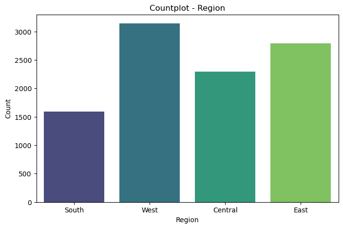

```python
plt.figure(figsize=(8,5))
sns.countplot(data=df_clean, x='Region', hue='Region', palette='viridis', legend=False)
plt.title('Countplot - Region')
plt.xlabel('Region')
plt.ylabel('Count')
plt.xticks(rotation=0)
plt.show()
```

### 🌍 Insight — Region

نمودار Countplot ستون Region نشان می‌دهد که توزیع تعداد سفارش‌ها میان چهار منطقهٔ اصلی Superstore یکسان نیست.

1. بیشترین تعداد سفارش مربوط به منطقهٔ West است.
2. منطقهٔ East در ردهٔ دوم قرار دارد، با فاصلهٔ نه‌چندان زیاد نسبت به West.
3. Central در رتبهٔ سوم قرار می‌گیرد و تعداد سفارشش کمتر از East و West است.
4. کمترین تعداد سفارش مربوط به منطقهٔ South است.

این نمودار نشان می‌دهد West و East بخش عمدهٔ سفارش‌های فروشگاه را تشکیل می‌دهند، در حالی که South کمترین سهم را دارد. دلیل این تفاوت (مانند جمعیت، تعداد مشتریان فعال یا سیاست‌های فروش منطقه‌ای) در این نمودار قابل بررسی نیست و برای تحلیل دقیق‌تر باید داده‌های تکمیلی بررسی شود. این بینش می‌تواند مسیر تحلیل‌های بعدی — مانند بررسی رابطهٔ Region با Profit و Sales — را مشخص کند.

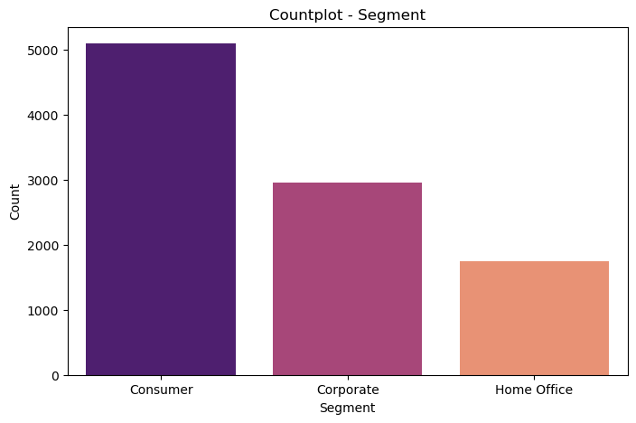

```python
plt.figure(figsize=(8,5))
sns.countplot(data=df_clean, x='Segment', hue='Segment', palette='magma', legend=False)
plt.title('Countplot - Segment')
plt.xlabel('Segment')
plt.ylabel('Count')
plt.xticks(rotation=0)
plt.show()
```

### 👥 Insight — Segment

نمودار Countplot ستون Segment نشان می‌دهد که توزیع تعداد سفارش‌ها میان سه گروه مشتری یکسان نیست.

1. بیشترین تعداد سفارش مربوط به گروه Consumer است که با فاصلهٔ زیادی از دو گروه دیگر در صدر قرار دارد.
2. گروه Corporate در ردهٔ دوم قرار می‌گیرد، با تعداد سفارشی به‌مراتب کمتر از Consumer.
3. کمترین تعداد سفارش مربوط به گروه Home Office است.

این نمودار نشان می‌دهد Consumer بخش عمدهٔ سفارش‌های فروشگاه را تشکیل می‌دهد، در حالی که Home Office سهم بسیار کوچک‌تری دارد. این توزیع می‌تواند مسیر تحلیل‌های بعدی — مانند بررسی رابطهٔ Segment با Profit یا Sales — را مشخص کند.

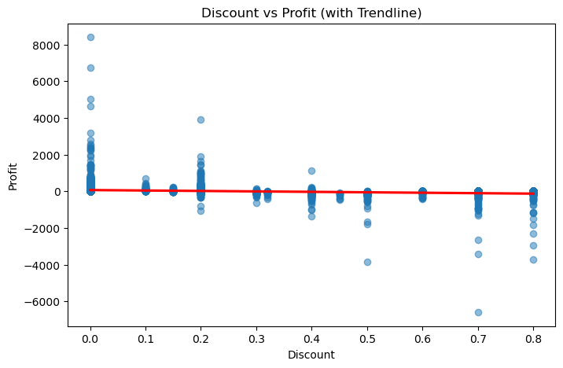

```python
plt.figure(figsize=(8,5))
sns.regplot(data=df_clean, x='Discount', y='Profit', scatter_kws={'alpha':0.5}, line_kws={'color':'red'})
plt.title('Discount vs Profit (with Trendline)')
plt.xlabel('Discount')
plt.ylabel('Profit')
plt.show()
```

### 📉 Insight — Discount vs Profit

نمودار Discount vs Profit نشان می‌دهد که رابطهٔ میان میزان تخفیف و سود محصولات در Superstore چگونه است. خط روند (Trendline) قرمز رنگ، جهت کلی این رابطه را نشان می‌دهد.

1. در تخفیف‌های پایین (نزدیک به ۰)، بیشتر نقاط در ناحیهٔ سود مثبت قرار دارند و حتی بالاترین مقادیر سود در این محدوده دیده می‌شود.
2. با افزایش تخفیف، پراکندگی نقاط به‌تدریج به سمت مقادیر منفی Profit کشیده می‌شود.
3. در تخفیف‌های بالا (بیش از ۵۰ درصد)، اکثریت نقاط در ناحیهٔ زیان قرار دارند و برخی از عمیق‌ترین مقادیر منفی سود نیز در همین محدوده دیده می‌شود.
4. خط روند قرمز نیز به‌وضوح یک شیب نزولی نشان می‌دهد که تأییدکنندهٔ رابطهٔ منفی کلی بین Discount و Profit است.

در مجموع، این نمودار نشان می‌دهد که افزایش تخفیف با کاهش سود همراه است، هرچند این رابطه قطعی نیست و برخی سفارش‌ها حتی با تخفیف کم نیز زیان‌ده بوده‌اند. این بینش می‌تواند در طراحی سیاست‌های تخفیف و تعیین سقف مناسب برای آن نقش مهمی داشته باشد.

## 📊 Insight نهایی پروژه Superstore

تحلیل داده‌های Superstore نشان می‌دهد که رفتار فروش، سودآوری، مشتریان و الگوهای ارسال در این فروشگاه تفاوت‌های قابل‌توجهی دارند و هر بخش بینش‌های مهمی برای تصمیم‌گیری‌های مدیریتی ارائه می‌دهد.

### 🟦 ۱. تحلیل Category

دسته‌بندی‌های اصلی شامل Furniture، Office Supplies و Technology هستند. فروش و سودآوری در دستهٔ Technology بالاتر از دو دستهٔ دیگر است. Furniture با وجود فروش قابل‌قبول، سودآوری پایینی دارد.

### 🟩 ۳. رفتار مشتریان (Segment)

بیشترین تعداد سفارش مربوط به گروه Consumer است. Corporate در ردهٔ دوم و Home Office کمترین سهم را در تعداد سفارش‌ها دارد.

### 🟧 ۴. تحلیل منطقه‌ای (Region)

West و East بیشترین تعداد سفارش را دارند. Central در رتبهٔ سوم و South کمترین تعداد سفارش را ثبت کرده است.

### 🟨 ۵. رفتار ارسال سفارش‌ها (Ship Mode)

بیشترین سفارش‌ها با روش Standard Class ارسال می‌شوند و با فاصلهٔ زیادی از سایر روش‌ها در صدر قرار دارد. First Class و Same Day کمترین سهم را دارند.

### 🟥 ۶. تأثیر تخفیف بر سود (Discount vs Profit)

نمودار Discount vs Profit و خط روند آن نشان می‌دهد که با افزایش تخفیف، سود عموماً کاهش می‌یابد و در تخفیف‌های بالا (بیش از ۵۰٪) اکثر سفارش‌ها زیان‌ده هستند.

## 🧩 جمع‌بندی مدیریتی

این تحلیل‌ها می‌توانند به تصمیم‌گیری‌های استراتژیک در حوزهٔ قیمت‌گذاری، مدیریت موجودی، بازاریابی و بهینه‌سازی سود کمک کنند.